# hmeq

```python
import pandas as pd
import numpy as np

import matplotlib.pyplot as plt
import seaborn as sns

from statsmodels.imputation.mice import MICEData
from scipy import stats
from sklearn.preprocessing import StandardScaler
from sklearn.model_selection import train_test_split
from imblearn.over_sampling import SMOTE

import warnings
warnings.filterwarnings('ignore')
```

## Dataset summary

The data set HMEQ reports characteristics and delinquency information for 5,960 home equity loans. A home equity loan is a loan where the obligor uses the equity of his or her home as the underlying collateral. The data set has the following characteristics:

◾ BAD: 1 = applicant defaulted on loan or seriously delinquent; 0 = applicant paid loan

◾ LOAN: Amount of the loan request

◾ MORTDUE: Amount due on existing mortgage

◾ VALUE: Value of current property

◾ REASON: DebtCon = debt consolidation; HomeImp = home improvement

◾ JOB: Occupational categories

◾ YOJ: Years at present job

◾ DEROG: Number of major derogatory reports

◾ DELINQ: Number of delinquent credit lines

◾ CLAGE: Age of oldest credit line in months

◾ NINQ: Number of recent credit inquiries

◾ CLNO: Number of credit lines

◾ DEBTINC: Debt-to-income ratio

source: http://www.creditriskanalytics.net/datasets-private2.html

## Loading data

```python
df = pd.read_csv('hmeq.csv')
```

```python
df.head(5)
```

|  | BAD | LOAN | MORTDUE | VALUE | REASON | JOB | YOJ | DEROG | DELINQ | CLAGE | NINQ | CLNO | DEBTINC |
| --- | --- | --- | --- | --- | --- | --- | --- | --- | --- | --- | --- | --- | --- |
| 0 | 1 | 1100 | 25860.0 | 39025.0 | HomeImp | Other | 10.5 | 0.0 | 0.0 | 94.366667 | 1.0 | 9.0 | NaN |
| 1 | 1 | 1300 | 70053.0 | 68400.0 | HomeImp | Other | 7.0 | 0.0 | 2.0 | 121.833333 | 0.0 | 14.0 | NaN |
| 2 | 1 | 1500 | 13500.0 | 16700.0 | HomeImp | Other | 4.0 | 0.0 | 0.0 | 149.466667 | 1.0 | 10.0 | NaN |
| 3 | 1 | 1500 | NaN | NaN | NaN | NaN | NaN | NaN | NaN | NaN | NaN | NaN | NaN |
| 4 | 0 | 1700 | 97800.0 | 112000.0 | HomeImp | Office | 3.0 | 0.0 | 0.0 | 93.333333 | 0.0 | 14.0 | NaN |

```python
df.info()
```

```
<class 'pandas.core.frame.DataFrame'>
RangeIndex: 5960 entries, 0 to 5959
Data columns (total 13 columns):
 #   Column   Non-Null Count  Dtype
---  ------   --------------  -----
 0   BAD      5960 non-null   int64
 1   LOAN     5960 non-null   int64
 2   MORTDUE  5442 non-null   float64
 3   VALUE    5848 non-null   float64
 4   REASON   5708 non-null   object
 5   JOB      5681 non-null   object
 6   YOJ      5445 non-null   float64
 7   DEROG    5252 non-null   float64
 8   DELINQ   5380 non-null   float64
 9   CLAGE    5652 non-null   float64
 10  NINQ     5450 non-null   float64
 11  CLNO     5738 non-null   float64
 12  DEBTINC  4693 non-null   float64
dtypes: float64(9), int64(2), object(2)
memory usage: 605.4+ KB
```

```python
df.describe()
```

|  | BAD | LOAN | MORTDUE | VALUE | YOJ | DEROG | DELINQ | CLAGE | NINQ | CLNO | DEBTINC |
| --- | --- | --- | --- | --- | --- | --- | --- | --- | --- | --- | --- |
| count | 5960.000000 | 5960.000000 | 5442.000000 | 5848.000000 | 5445.000000 | 5252.000000 | 5380.000000 | 5652.000000 | 5450.000000 | 5738.000000 | 4693.000000 |
| mean | 0.199497 | 18607.969799 | 73760.817200 | 101776.048741 | 8.922268 | 0.254570 | 0.449442 | 179.766275 | 1.186055 | 21.296096 | 33.779915 |
| std | 0.399656 | 11207.480417 | 44457.609458 | 57385.775334 | 7.573982 | 0.846047 | 1.127266 | 85.810092 | 1.728675 | 10.138933 | 8.601746 |
| min | 0.000000 | 1100.000000 | 2063.000000 | 8000.000000 | 0.000000 | 0.000000 | 0.000000 | 0.000000 | 0.000000 | 0.000000 | 0.524499 |
| 25% | 0.000000 | 11100.000000 | 46276.000000 | 66075.500000 | 3.000000 | 0.000000 | 0.000000 | 115.116702 | 0.000000 | 15.000000 | 29.140031 |
| 50% | 0.000000 | 16300.000000 | 65019.000000 | 89235.500000 | 7.000000 | 0.000000 | 0.000000 | 173.466667 | 1.000000 | 20.000000 | 34.818262 |
| 75% | 0.000000 | 23300.000000 | 91488.000000 | 119824.250000 | 13.000000 | 0.000000 | 0.000000 | 231.562278 | 2.000000 | 26.000000 | 39.003141 |
| max | 1.000000 | 89900.000000 | 399550.000000 | 855909.000000 | 41.000000 | 10.000000 | 15.000000 | 1168.233561 | 17.000000 | 71.000000 | 203.312149 |

## Exploratory analysis

```python
continuous_num_var = ['LOAN','MORTDUE','VALUE','YOJ','CLAGE','DEBTINC']
discrete_num_var = ['DEROG','DELINQ','NINQ','CLNO']
cat_var = ['REASON','JOB']
```

### Distributions of continuous variables

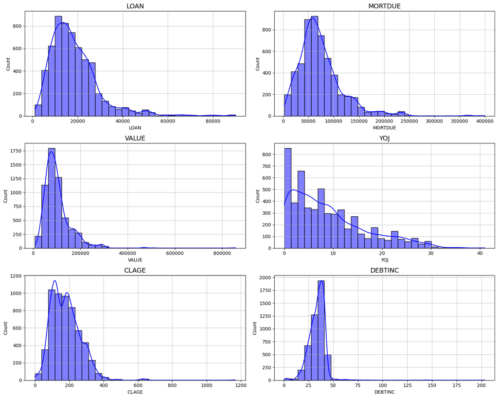

```python
fig, axes = plt.subplots(3, 2, figsize=(15, 12))
axes = axes.flatten()

for i, var in enumerate(continuous_num_var):
    sns.histplot(df[var], kde=True, bins=30, color='blue', edgecolor='black', ax=axes[i])
    axes[i].set_title(f'{var}', fontsize=14)
    axes[i].grid(True, alpha=0.7)

plt.tight_layout()
plt.show()
```

### Rozkłady zmiennych ilościowych skokowych

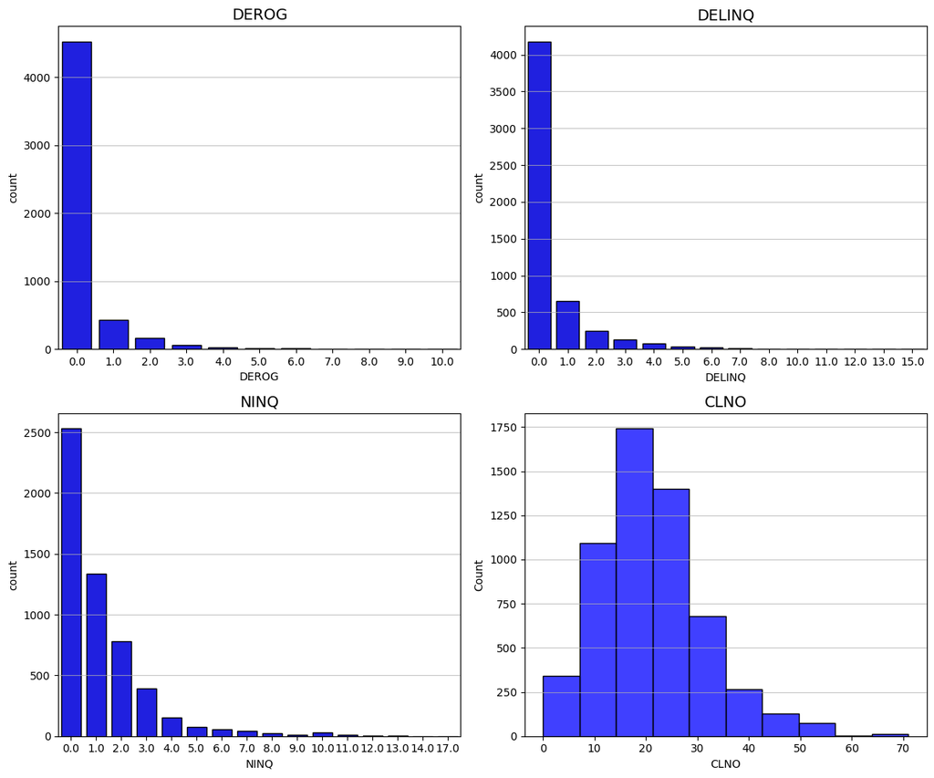

```python
fig, axes = plt.subplots(2, 2, figsize=(12, 10))
axes = axes.flatten()

sns.countplot(data=df, x='DEROG', ax=axes[0], color='blue', edgecolor='black')
axes[0].set_title('DEROG', fontsize=14)
axes[0].grid(axis='y', alpha=0.7)

sns.countplot(data=df, x='DELINQ', ax=axes[1], color='blue', edgecolor='black')
axes[1].set_title('DELINQ', fontsize=14)
axes[1].grid(axis='y', alpha=0.7)

sns.countplot(data=df, x='NINQ', ax=axes[2], color='blue', edgecolor='black')
axes[2].set_title('NINQ', fontsize=14)
axes[2].grid(axis='y', alpha=0.7)

sns.histplot(data=df, x='CLNO', kde=False, bins = 10, ax=axes[3], color='blue', edgecolor='black')
axes[3].set_title('CLNO', fontsize=14)
axes[3].grid(axis='y', alpha=0.7)

plt.tight_layout()
plt.show()
```

### Distributions of categorical variables

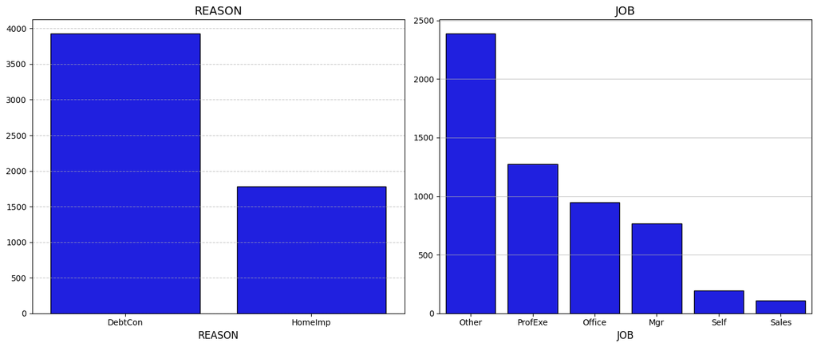

```python
fig, axes = plt.subplots(1, 2, figsize=(14, 6))

cat1_counts = df[cat_var[0]].value_counts()
sns.barplot(x=cat1_counts.index, y=cat1_counts.values, ax=axes[0], color='blue', edgecolor='black')
axes[0].set_title(f'{cat_var[0]}', fontsize=14)
axes[0].set_xlabel(cat_var[0], fontsize=12)
axes[0].grid(axis='y', linestyle='--', alpha=0.7)

cat2_counts = df[cat_var[1]].value_counts()
sns.barplot(x=cat2_counts.index, y=cat2_counts.values, ax=axes[1], color='blue', edgecolor='black')
axes[1].set_title(f'{cat_var[1]}', fontsize=14)
axes[1].set_xlabel(cat_var[1], fontsize=12)
axes[1].grid(axis='y', alpha=0.7)

plt.tight_layout()
plt.show()
```

### Target variable

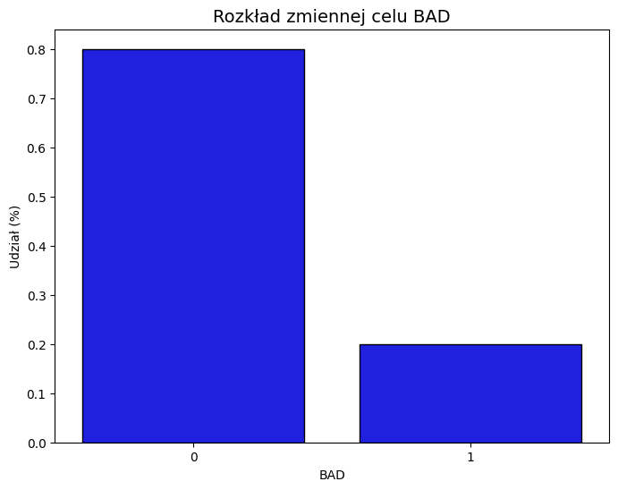

```python
counts = df['BAD'].value_counts(normalize=True)
plt.figure(figsize=(8, 6))
sns.barplot(x=counts.index, y=counts.values, color='blue', edgecolor='black')
plt.ylabel('Udział (%)')
plt.title('Rozkład zmiennej celu BAD', fontsize=14)
plt.show()
```

### Missing values

```python
df.isna().sum()
```

```
BAD           0
LOAN          0
MORTDUE     518
VALUE       112
REASON      252
JOB         279
YOJ         515
DEROG       708
DELINQ      580
CLAGE       308
NINQ        510
CLNO        222
DEBTINC    1267
dtype: int64
```

Due to the missing data present in most variables, multiple imputation is used, as in this case simple imputation methods (mean or median) could lead to biased estimators.

```python
mice_data = MICEData(df.select_dtypes(exclude=['object','category']))
mice_data.update_all()

df_imputed = mice_data.data
```

```python
df_combined = pd.concat([df_imputed, df.select_dtypes(include=['object','category'])], axis=1)
```

The remaining missing values in the categorical variables will be replaced with the most frequent category.

```python
df_combined['REASON'].fillna(df_combined['REASON'].mode()[0], inplace=True)
df_combined['JOB'].fillna(df_combined['JOB'].mode()[0], inplace=True)
```

```python
df_combined.isna().sum()
```

```
BAD        0
LOAN       0
MORTDUE    0
VALUE      0
YOJ        0
DEROG      0
DELINQ     0
CLAGE      0
NINQ       0
CLNO       0
DEBTINC    0
REASON     0
JOB        0
dtype: int64
```

### Duplicates

```python
df_combined.duplicated().sum()
```

```
np.int64(0)
```

### Outliers

```python
num_var = continuous_num_var + discrete_num_var
```

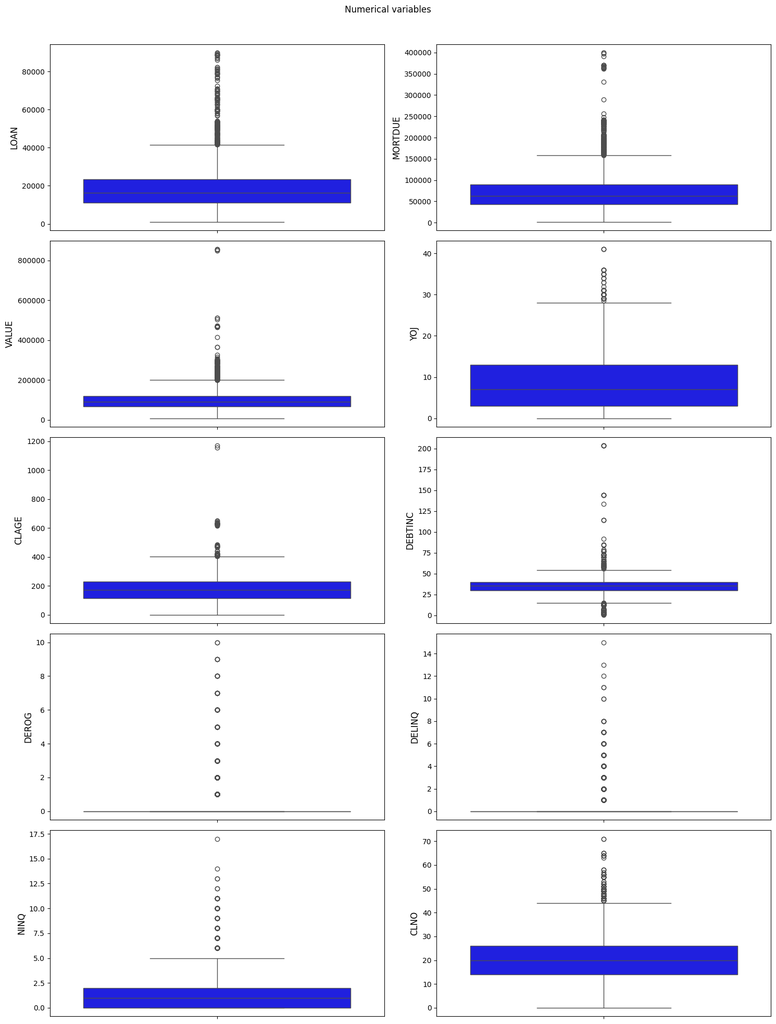

```python
fig, axes = plt.subplots(5, 2, figsize=(15, 20))
axes = axes.flatten()

for i, var in enumerate(num_var):
    sns.boxplot(data=df_combined, y=var, ax=axes[i], color='blue')
    axes[i].set_xlabel('')
    axes[i].set_ylabel(var, fontsize=12)

plt.tight_layout(rect=[0, 0, 1, 0.95])
plt.suptitle('Numerical variables')
plt.show()
```

```python
var_outliers = ['LOAN','MORTDUE','VALUE','CLAGE','DEBTINC','CLNO']
```

```python
# 3 sigma rule
df_combined = df_combined[(np.abs(stats.zscore(df_combined[var_outliers])) < 3).all(axis=1)]
```

```python
df_combined.info()
```

```
<class 'pandas.core.frame.DataFrame'>
Index: 5622 entries, 0 to 5864
Data columns (total 13 columns):
 #   Column   Non-Null Count  Dtype
---  ------   --------------  -----
 0   BAD      5622 non-null   int64
 1   LOAN     5622 non-null   int64
 2   MORTDUE  5622 non-null   float64
 3   VALUE    5622 non-null   float64
 4   YOJ      5622 non-null   float64
 5   DEROG    5622 non-null   float64
 6   DELINQ   5622 non-null   float64
 7   CLAGE    5622 non-null   float64
 8   NINQ     5622 non-null   float64
 9   CLNO     5622 non-null   float64
 10  DEBTINC  5622 non-null   float64
 11  REASON   5622 non-null   object
 12  JOB      5622 non-null   object
dtypes: float64(9), int64(2), object(2)
memory usage: 614.9+ KB
```

## Standarization and encoding

```python
scaler = StandardScaler()
df_combined[num_var] = scaler.fit_transform(df_combined[num_var])
```

```python
df_combined = pd.get_dummies(df_combined, columns=cat_var, drop_first=True)
```

```python
df_combined = df_combined.astype(float)
```

```python
df_combined.info()
```

```
<class 'pandas.core.frame.DataFrame'>
Index: 5622 entries, 0 to 5864
Data columns (total 17 columns):
 #   Column          Non-Null Count  Dtype
---  ------          --------------  -----
 0   BAD             5622 non-null   float64
 1   LOAN            5622 non-null   float64
 2   MORTDUE         5622 non-null   float64
 3   VALUE           5622 non-null   float64
 4   YOJ             5622 non-null   float64
 5   DEROG           5622 non-null   float64
 6   DELINQ          5622 non-null   float64
 7   CLAGE           5622 non-null   float64
 8   NINQ            5622 non-null   float64
 9   CLNO            5622 non-null   float64
 10  DEBTINC         5622 non-null   float64
 11  REASON_HomeImp  5622 non-null   float64
 12  JOB_Office      5622 non-null   float64
 13  JOB_Other       5622 non-null   float64
 14  JOB_ProfExe     5622 non-null   float64
 15  JOB_Sales       5622 non-null   float64
 16  JOB_Self        5622 non-null   float64
dtypes: float64(17)
memory usage: 790.6 KB
```

## Customer segmentation

```python
X = df_combined.drop(['BAD'],axis=1)
```

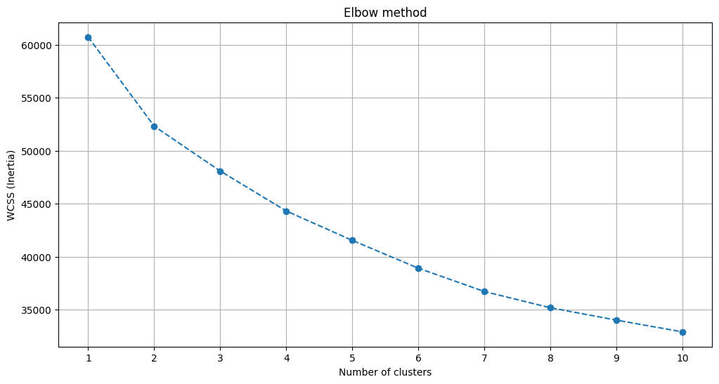

```python
from sklearn.cluster import KMeans
from sklearn.metrics import silhouette_score

wcss = [] #Within-Cluster Sum of Squares
silhouette_scores = []
max_clusters = 10

for n_clusters in range(1, max_clusters + 1):
    kmeans = KMeans(n_clusters=n_clusters, random_state=42, n_init=10)
    kmeans.fit(X)
    wcss.append(kmeans.inertia_)

    if n_clusters > 1:
        silhouette_scores.append(silhouette_score(X, kmeans.labels_))

plt.figure(figsize=(12, 6))
plt.plot(range(1, max_clusters + 1), wcss, marker='o', linestyle='--')
plt.title('Elbow method')
plt.xlabel('Number of clusters')
plt.ylabel('WCSS (Inertia)')
plt.xticks(range(1, max_clusters + 1))
plt.grid()
plt.show()
```

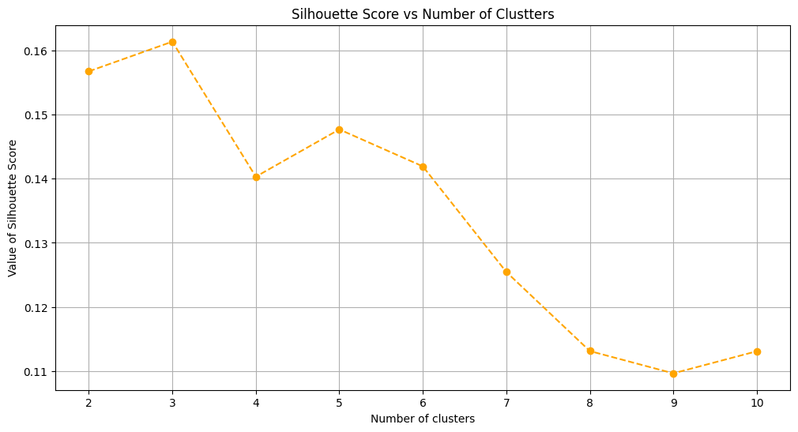

```python
if silhouette_scores:
    plt.figure(figsize=(12, 6))
    plt.plot(range(2, max_clusters + 1), silhouette_scores, marker='o', linestyle='--', color='orange')
    plt.title('Silhouette Score vs Number of Clustters')
    plt.xlabel('Number of clusters')
    plt.ylabel('Value of Silhouette Score')
    plt.xticks(range(2, max_clusters + 1))
    plt.grid()
    plt.show()
```

```python
from sklearn.decomposition import PCA
```

```python
optimal_clusters = 2

kmeans = KMeans(n_clusters=optimal_clusters, random_state=42, n_init=10)
kmeans.fit(X)
cluster_labels = kmeans.labels_

pca = PCA(n_components=2)
X_pca = pca.fit_transform(X)
```

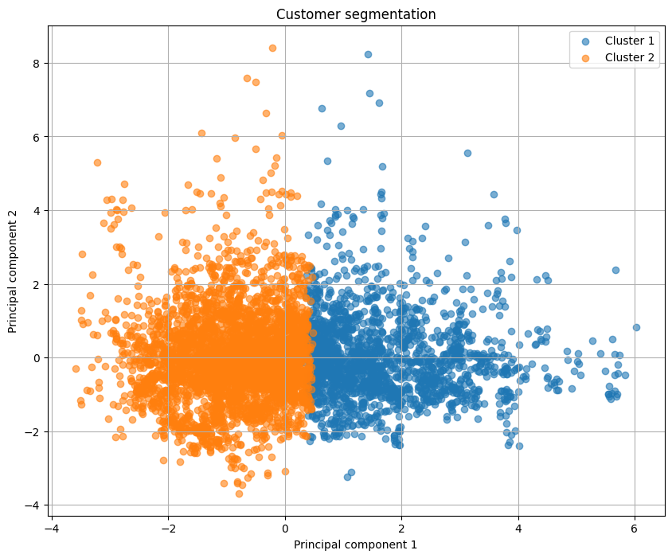

```python
plt.figure(figsize=(10, 8))
for cluster in range(optimal_clusters):
    plt.scatter(
        X_pca[cluster_labels == cluster, 0],
        X_pca[cluster_labels == cluster, 1],
        label=f'Cluster {cluster+1}',
        alpha=0.6
    )

plt.title('Customer segmentation')
plt.xlabel('Principal component 1')
plt.ylabel('Principal component 2')
plt.legend()
plt.grid()
plt.show()
```

```python
X['CLUSTER'] = cluster_labels
```

```python
df_segments = pd.concat([X,df_combined['BAD']],axis=1)
```

```python
df_segments[num_var] = scaler.inverse_transform(df_segments[num_var])
```

```python
cluster_target_crosstab = pd.crosstab(df_segments['CLUSTER'], df_segments['BAD'], normalize='index')
print(cluster_target_crosstab)
```

```
BAD           0.0       1.0
CLUSTER
0        0.828692  0.171308
1        0.798871  0.201129
```

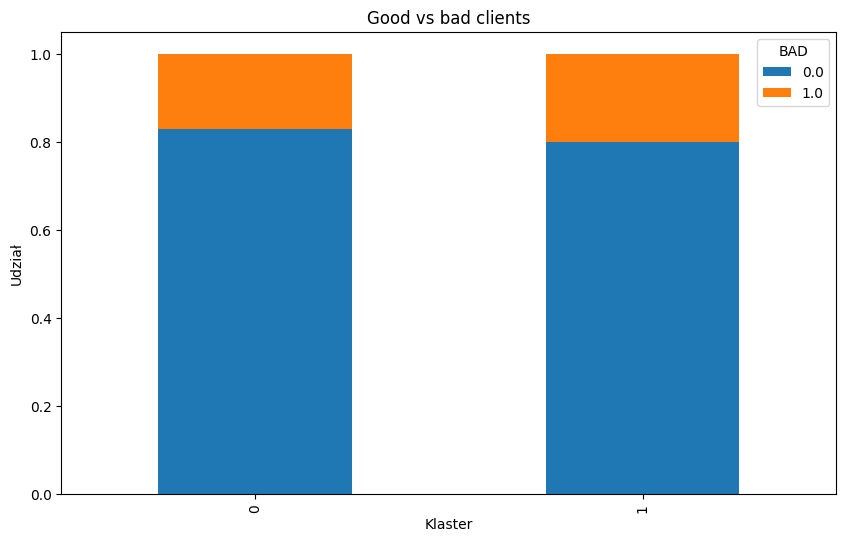

```python
cluster_target_crosstab.plot(kind='bar', stacked=True, figsize=(10, 6))
plt.title('Good vs bad clients')
plt.ylabel('Udział')
plt.xlabel('Klaster')
plt.legend(title='BAD')
plt.show()
```

```python
cluster_summary = df_segments.groupby('CLUSTER')[num_var].mean()
target_summary = df_segments.groupby('CLUSTER')['BAD'].value_counts(normalize=True).unstack()

print("Summary between clusters:")
print(cluster_summary)
```

```
Summary between clusters:
                 LOAN        MORTDUE          VALUE       YOJ       CLAGE  \
CLUSTER
0        21351.550184  103319.194572  143548.414346  9.060168  202.590446
1        15568.324818   48449.522979   73197.771589  8.908752  161.763701

           DEBTINC     DEROG    DELINQ      NINQ       CLNO
CLUSTER
0        36.310792  0.191802  0.480294  1.312139  26.778770
1        32.891146  0.279107  0.398494  1.082011  17.791342
```

```python
target_summary
```

| BAD CLUSTER | 0.0 | 1.0 |
| --- | --- | --- |
| 0 | 0.828692 | 0.171308 |
| 1 | 0.798871 | 0.201129 |

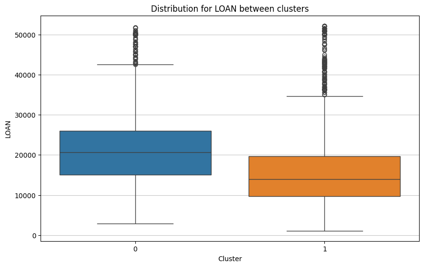

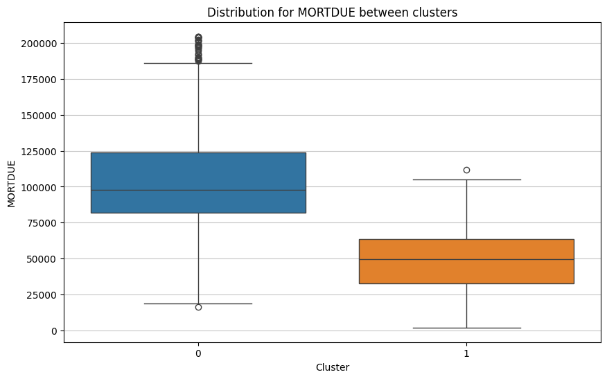

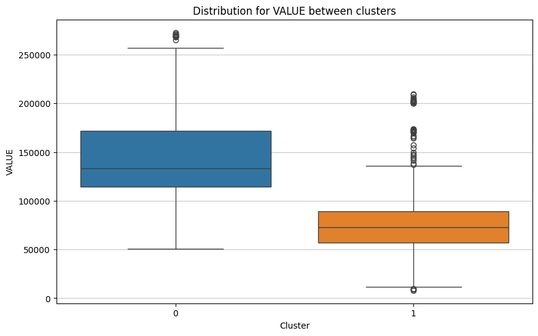

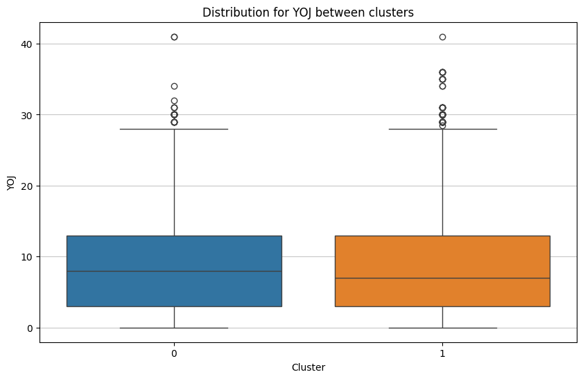

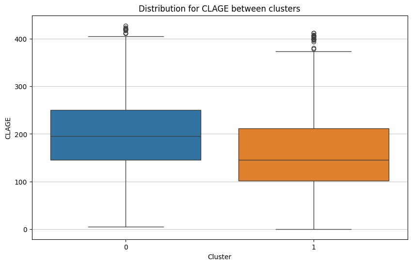

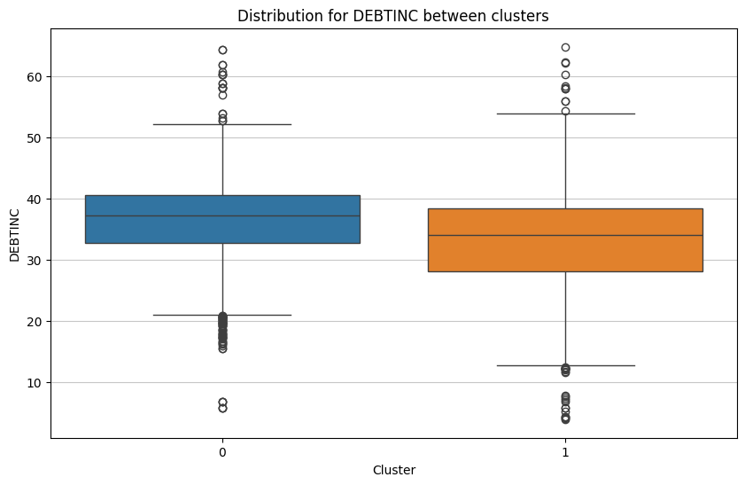

```python
for var in continuous_num_var:
    plt.figure(figsize=(10, 6))
    sns.boxplot(data=df_segments, x='CLUSTER', y=var, palette='tab10')
    plt.title(f'Distribution for {var} between clusters')
    plt.xlabel('Cluster')
    plt.ylabel(var)
    plt.grid(axis='y', alpha=0.7)
    plt.show()
```

```python
categorical_features_encoded = ['REASON_HomeImp', 'JOB_Office', 'JOB_Other','JOB_ProfExe', 'JOB_Sales', 'JOB_Self']
```

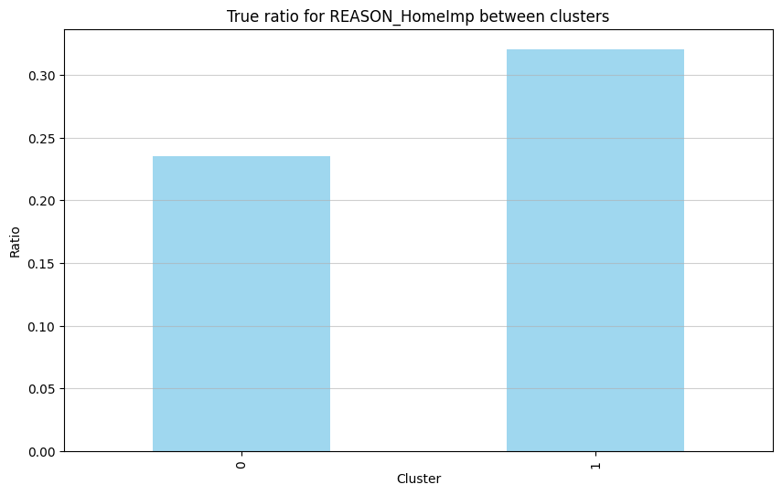

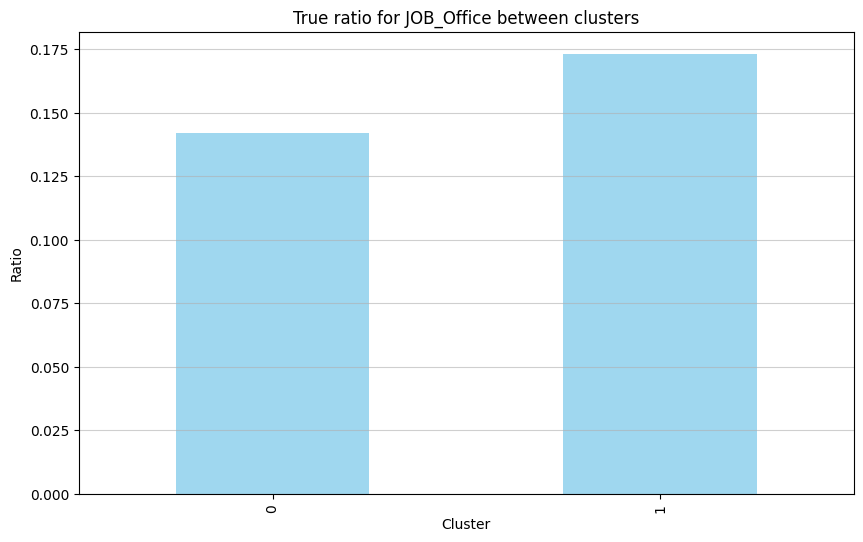

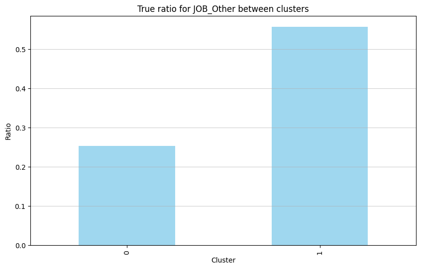

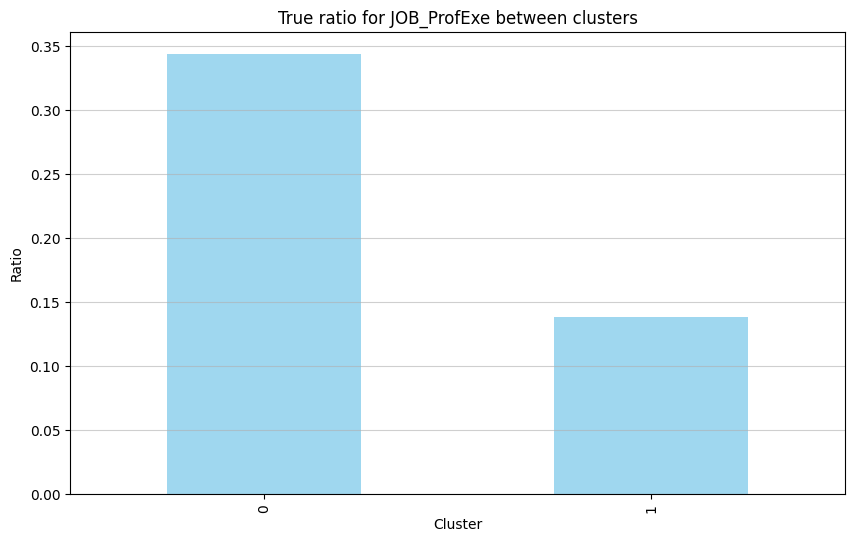

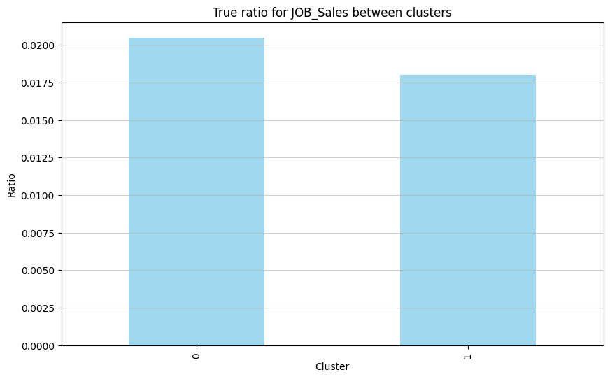

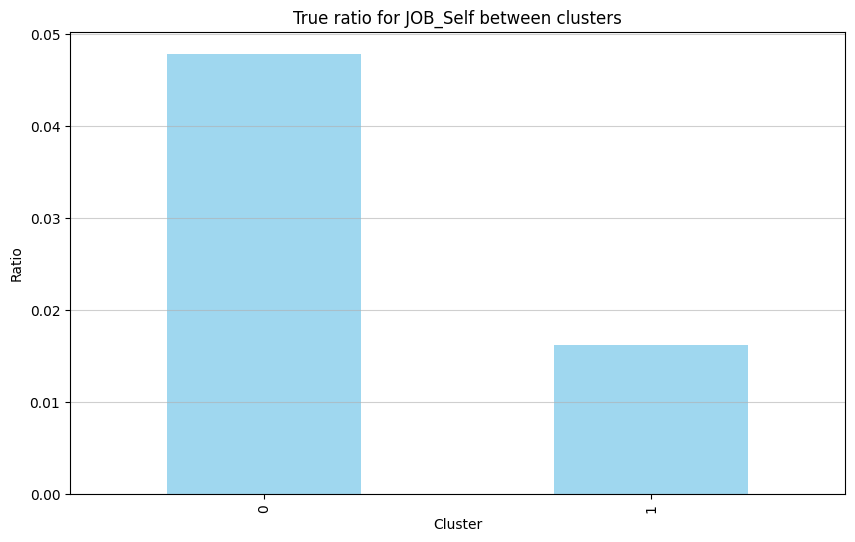

```python
for var in categorical_features_encoded:
    cluster_proportions = df_segments.groupby('CLUSTER')[var].mean()

    plt.figure(figsize=(10, 6))
    cluster_proportions.plot(kind='bar', color='skyblue', alpha=0.8)
    plt.title(f'True ratio for {var} between clusters')
    plt.xlabel('Cluster')
    plt.ylabel('Ratio')
    plt.grid(axis='y', alpha=0.6)
    plt.show()
```

## Split and oversampling

```python
## Split
X = df_combined.drop(['BAD'],axis=1)
y = df_combined['BAD']
X_train, X_test, y_train, y_test = train_test_split(X, y, test_size=0.2, stratify=df_combined['BAD'], random_state=42)
## Oversampling
y_train.value_counts(normalize=True)
smote = SMOTE(random_state=42)

X_train_smote, y_train_smote = smote.fit_resample(X_train, y_train)
y_train_smote.value_counts(normalize=True)
X_train_smote.shape
```

```
(7276, 16)
```

# Classification models

```python
from sklearn.ensemble import RandomForestClassifier, GradientBoostingClassifier
from sklearn.model_selection import RandomizedSearchCV
from scipy.stats import randint, uniform, loguniform
from sklearn.metrics import classification_report,confusion_matrix, ConfusionMatrixDisplay,roc_curve, auc, recall_score, roc_auc_score
```

```python
rf = RandomForestClassifier(
    n_jobs=-1,
    random_state=42,
)

rf_param_dist = {
    "n_estimators": randint(200, 1001),
    "max_depth": randint(3, 31),
    "min_samples_split": randint(2, 21),
    "min_samples_leaf": randint(1, 21),
    "max_features": np.linspace(1, X_train.shape[1],16).astype(int),
    "bootstrap": [True, False]
}
```

```python
rf_search = RandomizedSearchCV(
    estimator=rf,
    param_distributions=rf_param_dist,
    n_iter=50,
    scoring="roc_auc",     #PD
    cv=3,
    n_jobs=-1,
    random_state=42
)

rf_search.fit(X_train, y_train)
best_rf = rf_search.best_estimator_
print(rf_search.best_params_, rf_search.best_score_)
```

```
{'bootstrap': False, 'max_depth': 30, 'max_features': np.int64(5), 'min_samples_leaf': 1, 'min_samples_split': 13, 'n_estimators': 513} 0.9292485583839335
```

```python
y_pred_test_ = best_rf.predict(X_test)
recall_test = recall_score(y_test, y_pred_test_)
recall_test
```

```
0.5488372093023256
```

```python
print(classification_report(y_test, y_pred_test_))
```

```
              precision    recall  f1-score   support

         0.0       0.90      0.98      0.94       910
         1.0       0.86      0.55      0.67       215

    accuracy                           0.90      1125
   macro avg       0.88      0.76      0.80      1125
weighted avg       0.89      0.90      0.89      1125
```

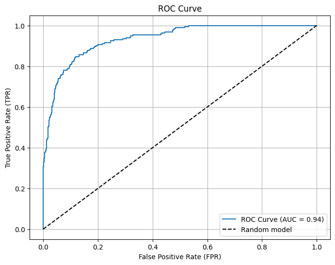

```python
y_pred_t_proba = best_rf.predict_proba(X_test)

fpr, tpr, thresholds = roc_curve(y_test, y_pred_t_proba[:,1])
rf_roc_auc = roc_auc_score(y_test, y_pred_t_proba[:,1])
roc_auc = auc(fpr, tpr)

plt.figure(figsize=(8, 6))
plt.plot(fpr, tpr, label=f'ROC Curve (AUC = {roc_auc:.2f})')
plt.plot([0, 1], [0, 1], 'k--', label="Random model")
plt.xlabel("False Positive Rate (FPR)")
plt.ylabel("True Positive Rate (TPR)")
plt.title("ROC Curve")
plt.legend(loc="lower right")
plt.grid()
plt.show()
```

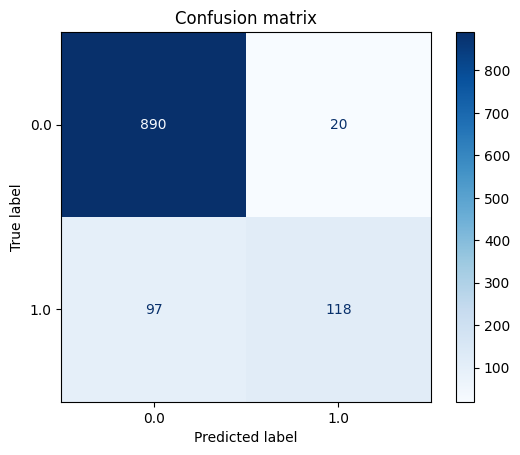

```python
cm = confusion_matrix(y_test,y_pred_test_)
disp = ConfusionMatrixDisplay(confusion_matrix=cm, display_labels=best_rf.classes_)
disp.plot(cmap='Blues')
plt.title("Confusion matrix")
plt.show()
```

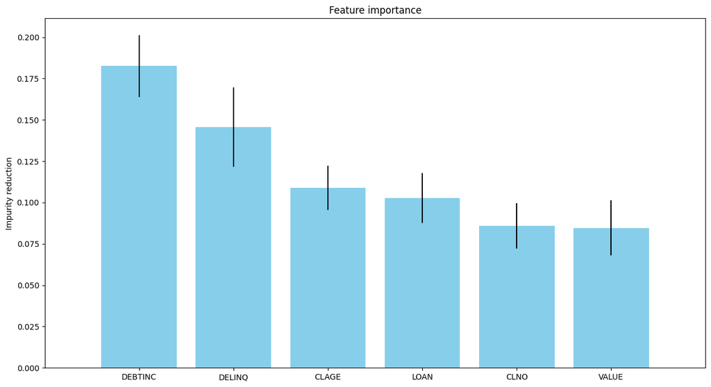

```python
importances = best_rf.feature_importances_
std = np.std([tree.feature_importances_ for tree in best_rf.estimators_], axis=0)
indices = np.argsort(importances)[::-1]

num_feat = 6
plt.figure(figsize=[15, 8])
plt.title("Feature importance")
plt.bar(
    range(num_feat)[:num_feat],
    importances[indices][:num_feat],
    color="skyblue",
    yerr=std[indices][:num_feat],
    align="center",
)
plt.xticks(range(num_feat)[:num_feat], X_train.columns[indices[:num_feat]])
plt.xlim([-1, num_feat])
plt.ylabel("Impurity reduction")
```

## SMOTE RF

```python
rf = RandomForestClassifier(
    n_jobs=-1,
    random_state=42,
)

rf_param_dist = {
    "n_estimators": randint(200, 1001),
    "max_depth": randint(3, 31),
    "min_samples_split": randint(2, 21),
    "min_samples_leaf": randint(1, 21),
    "max_features": np.linspace(1, X_train.shape[1],16).astype(int),
    "bootstrap": [True, False]
}

smote_rf_search = RandomizedSearchCV(
    estimator=rf,
    param_distributions=rf_param_dist,
    n_iter=50,
    scoring="roc_auc",     #PD
    cv=3,
    n_jobs=-1,
    random_state=42
)

smote_rf_search.fit(X_train_smote, y_train_smote)
smote_best_rf = smote_rf_search.best_estimator_
print(smote_rf_search.best_params_, smote_rf_search.best_score_)
```

[output not shown]

```python
y_pred_test_ = smote_best_rf.predict(X_test)
print(classification_report(y_test, y_pred_test_))
```

[output not shown]

```python
y_pred_t_proba = smote_best_rf.predict_proba(X_test)
smote_recall_test = recall_score(y_test, y_pred_test_)
smote_recall_test
```

```
0.6744186046511628
```

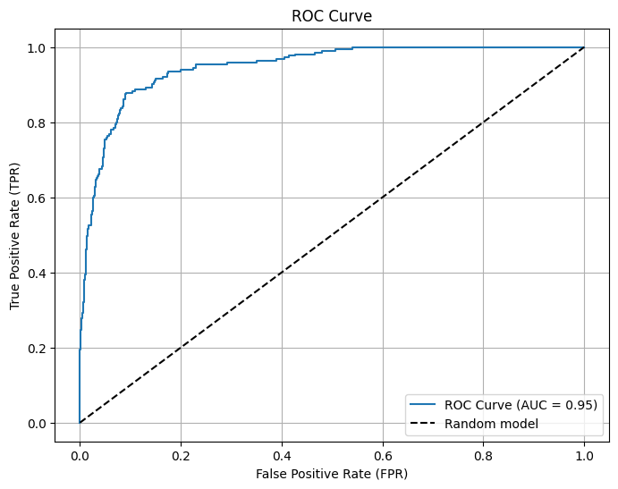

```python
y_pred_t_proba = smote_best_rf.predict_proba(X_test)

fpr, tpr, thresholds = roc_curve(y_test, y_pred_t_proba[:,1])
smote_rf_roc_auc = roc_auc_score(y_test, y_pred_t_proba[:,1])
roc_auc = auc(fpr, tpr)

plt.figure(figsize=(8, 6))
plt.plot(fpr, tpr, label=f'ROC Curve (AUC = {roc_auc:.2f})')
plt.plot([0, 1], [0, 1], 'k--', label="Random model")
plt.xlabel("False Positive Rate (FPR)")
plt.ylabel("True Positive Rate (TPR)")
plt.title("ROC Curve")
plt.legend(loc="lower right")
plt.grid()
plt.show()
```

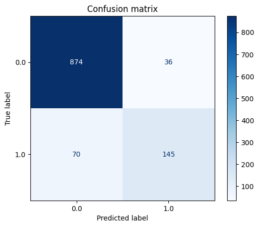

```python
cm = confusion_matrix(y_test,y_pred_test_)
disp = ConfusionMatrixDisplay(confusion_matrix=cm, display_labels=best_rf.classes_)
disp.plot(cmap='Blues')
plt.title("Confusion matrix")
plt.show()
```

## GBM

```python
gbm = GradientBoostingClassifier(
    random_state=42
)

gbm_param_dist = {
    "n_estimators": randint(100, 801),
    "learning_rate": uniform(0.01, 0.29),
    "max_depth": randint(3, 11),
    "min_samples_split": randint(2, 21),
    "min_samples_leaf": randint(1, 21),
    "subsample": uniform(0.5, 0.5),
    "max_features": np.linspace(1, X_train.shape[1], 16).astype(int)
}

gbm_search = RandomizedSearchCV(
    estimator=gbm,
    param_distributions=gbm_param_dist,
    n_iter=50,
    scoring="roc_auc",
    cv=3,
    n_jobs=-1,
    random_state=42
)
```

```python
gbm_search.fit(X_train, y_train)
best_gbm = gbm_search.best_estimator_

print(gbm_search.best_params_, gbm_search.best_score_)
```

```
{'learning_rate': np.float64(0.10018487329754203), 'max_depth': 10, 'max_features': np.int64(5), 'min_samples_leaf': 3, 'min_samples_split': 13, 'n_estimators': 646, 'subsample': np.float64(0.7361074625809747)} 0.951116998675217
```

```python
y_pred_test_ = best_gbm.predict(X_test)
gbm_recall_test = recall_score(y_test, y_pred_test_)
gbm_recall_test
```

```
0.6046511627906976
```

```python
print(classification_report(y_test, y_pred_test_))
```

```
              precision    recall  f1-score   support

         0.0       0.91      0.99      0.95       910
         1.0       0.92      0.60      0.73       215

    accuracy                           0.91      1125
   macro avg       0.92      0.80      0.84      1125
weighted avg       0.92      0.91      0.91      1125
```

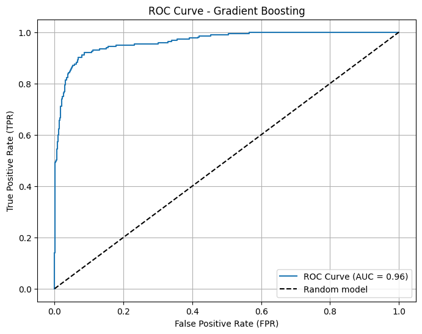

```python
y_pred_t_proba = best_gbm.predict_proba(X_test)

fpr, tpr, thresholds = roc_curve(y_test, y_pred_t_proba[:, 1])
gbm_roc_auc = roc_auc_score(y_test, y_pred_t_proba[:,1])
roc_auc = auc(fpr, tpr)

plt.figure(figsize=(8, 6))
plt.plot(fpr, tpr, label=f'ROC Curve (AUC = {roc_auc:.2f})')
plt.plot([0, 1], [0, 1], 'k--', label="Random model")
plt.xlabel("False Positive Rate (FPR)")
plt.ylabel("True Positive Rate (TPR)")
plt.title("ROC Curve - Gradient Boosting")
plt.legend(loc="lower right")
plt.grid()
plt.show()
```

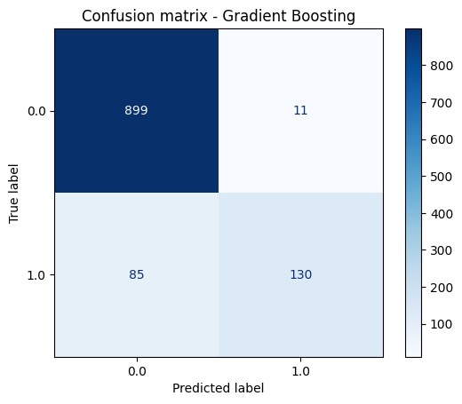

```python
cm = confusion_matrix(y_test, y_pred_test_)
disp = ConfusionMatrixDisplay(confusion_matrix=cm, display_labels=best_gbm.classes_)
disp.plot(cmap='Blues')
plt.title("Confusion matrix - Gradient Boosting")
plt.show()
```

## SMOTE GBM

```python
gbm = GradientBoostingClassifier(
    random_state=42
)

gbm_param_dist = {
    "n_estimators": randint(100, 801),
    "learning_rate": uniform(0.01, 0.29),
    "max_depth": randint(3, 11),
    "min_samples_split": randint(2, 21),
    "min_samples_leaf": randint(1, 21),
    "subsample": uniform(0.5, 0.5),
    "max_features": np.linspace(1, X_train.shape[1], 16).astype(int)
}

smote_gbm_search = RandomizedSearchCV(
    estimator=gbm,
    param_distributions=gbm_param_dist,
    n_iter=50,
    scoring="roc_auc",
    cv=3,
    n_jobs=-1,
    random_state=42
)
smote_gbm_search.fit(X_train_smote, y_train_smote)
smote_best_gbm = smote_gbm_search.best_estimator_

print(smote_gbm_search.best_params_, smote_gbm_search.best_score_)
```

```
{'learning_rate': np.float64(0.08159405822319434), 'max_depth': 9, 'max_features': np.int64(2), 'min_samples_leaf': 3, 'min_samples_split': 18, 'n_estimators': 712, 'subsample': np.float64(0.6424202471887338)} 0.9957144234611123
```

```python
y_pred_test_ = smote_best_gbm.predict(X_test)
smote_gbm_recall_test = recall_score(y_test, y_pred_test_)
smote_gbm_recall_test
```

```
0.7069767441860465
```

```python
print(classification_report(y_test, y_pred_test_))
```

```
              precision    recall  f1-score   support

         0.0       0.93      0.99      0.96       910
         1.0       0.94      0.71      0.81       215

    accuracy                           0.94      1125
   macro avg       0.94      0.85      0.89      1125
weighted avg       0.94      0.94      0.93      1125
```

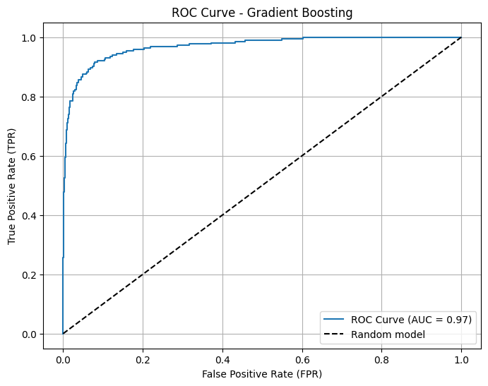

```python
y_pred_t_proba = smote_best_gbm.predict_proba(X_test)
smote_gbm_auc_roc = roc_auc_score(y_test, y_pred_t_proba[:,1])
fpr, tpr, thresholds = roc_curve(y_test, y_pred_t_proba[:, 1])
roc_auc = auc(fpr, tpr)

plt.figure(figsize=(8, 6))
plt.plot(fpr, tpr, label=f'ROC Curve (AUC = {roc_auc:.2f})')
plt.plot([0, 1], [0, 1], 'k--', label="Random model")
plt.xlabel("False Positive Rate (FPR)")
plt.ylabel("True Positive Rate (TPR)")
plt.title("ROC Curve - Gradient Boosting")
plt.legend(loc="lower right")
plt.grid()
plt.show()
```

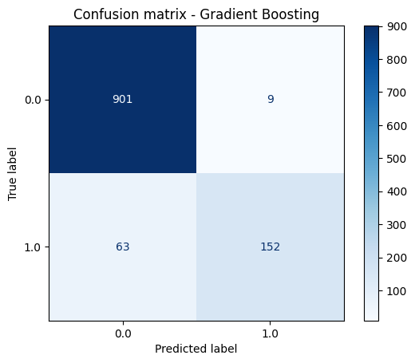

```python
cm = confusion_matrix(y_test, y_pred_test_)
disp = ConfusionMatrixDisplay(confusion_matrix=cm, display_labels=best_gbm.classes_)
disp.plot(cmap='Blues')
plt.title("Confusion matrix - Gradient Boosting")
plt.show()
```

## Summary

[figure not shown]

```python
standard = [recall_test, gbm_recall_test]
smote    = [smote_recall_test, smote_gbm_recall_test]

auc_standard = [rf_roc_auc, gbm_roc_auc]
auc_smote    = [smote_rf_roc_auc, smote_gbm_auc_roc]

labels = ["RF", "GBM"]

x = np.arange(len(labels))
width = 0.35

plt.figure(figsize=(9,6))
bars1 = plt.bar(x - width/2, standard, width, label="Standard Recall", color="tab:blue")
bars2 = plt.bar(x + width/2, smote, width, label="SMOTE Recall", color="tab:orange")

plt.xticks(x, labels)
plt.ylabel("Recall")
plt.title("Recall Comparison With ROC AUC Values")
plt.ylim(0, 1)

plt.grid(axis='y', linestyle='--', alpha=0.6)

for i, v in enumerate(standard):
    plt.text(x[i] - width/2, v + 0.02, f"{v:.3f}", ha='center', fontsize=10)
    plt.text(x[i] - width/2, 0.02, f"AUC={auc_standard[i]:.3f}", ha='center', color='white')

for i, v in enumerate(smote):
    plt.text(x[i] + width/2, v + 0.02, f"{v:.3f}", ha='center', fontsize=10)
    plt.text(x[i] + width/2, 0.02, f"AUC={auc_smote[i]:.3f}", ha='center', color='white')

plt.legend()
plt.show()
```